# BDSI Workshop Summary

2024 Q1

demo

Author

Emi Tanaka

Biological Data Science Institute

Date

28th March 2024

Executive Summary

This report contains summary of BDSI workshop registration to date.

## Overview

To ensure that workshop offerings are effective, this report is part of a regular series that presents the summary of registration from workshops where such data are available. The registration summary to date are shown in Section 2.

## Registration summary

The latest workshops offered in April 2024 are listed in Table 1. The advertisement was initially sent to the Research School of Biology (RSB) and John Curtin School of Medical Research (JCSMR) student cohorts. The workshop was more widely advertised on 12th March 2024. The registration closed on 22nd March 2024.

There are currently **97 participants** registered across the 4 workshops. The distribution of the registration for each workshop by affiliation and role are shown in Table 1 and Table 2, respectively.

Table 1: The number of registration by workshop and affiliation.

| Workshop | RSB | JCSMR | Other | Total |
| --- | --- | --- | --- | --- |
| Data Wrangling with R | 40 | 29 | 17 | 86 |
| Introduction to R Programming | 34 | 32 | 18 | 84 |
| Data Visualisation with R | 40 | 26 | 18 | 84 |
| Reproducible Research with Quarto | 32 | 20 | 13 | 65 |

Table 2: The number of registration by workshop and role.

| Workshop | Postgrad | Honours | Other |
| --- | --- | --- | --- |
| Data Wrangling with R | 33 | 36 | 17 |
| Introduction to R Programming | 33 | 37 | 14 |
| Data Visualisation with R | 32 | 35 | 17 |
| Reproducible Research with Quarto | 25 | 28 | 12 |

We see in Figure 1 that most participants attend all four workshops. There is a small, non-neglible, proportion that attend just the R workshops but not the Reproducible Research with Quarto workshops.

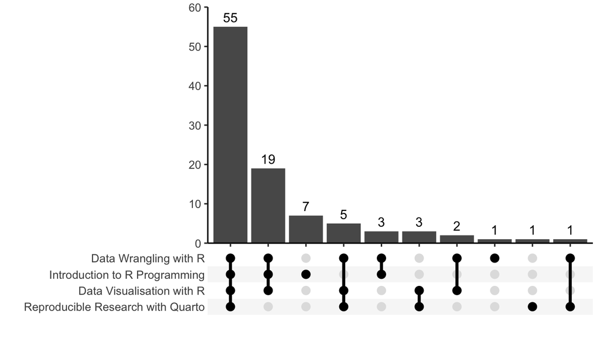

Figure 1: This plot shows the number of registrations for the combinations of workshops selected to attend.

The distribution of the confidence in R skill by all, role or affiliation are shown in Figure 2. In general, the confidence is skewed to the right (as expected).

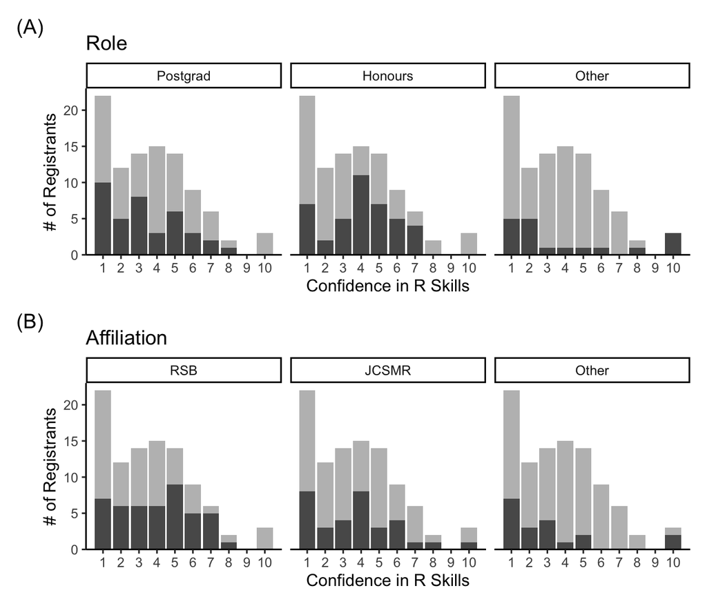

Figure 2: The above darker bars show the distribution of the confidence in R skill by (A) role or (B) affiliation. The grey bars are the distribution of all participants regardless of their role or affiliation.

## Computational details

This report was written using Quarto version 1.4.545 (Allaire 2023). The data wrangling and visualisation was done using R and `tidyverse` R package (Wickham et al. 2019).

## References

Allaire, JJ. 2023. *Quarto: R Interface to ’Quarto’ Markdown Publishing System*. https://CRAN.R-project.org/package=quarto.

Wickham, Hadley, Mara Averick, Jennifer Bryan, Winston Chang, Lucy D’Agostino McGowan, Romain François, Garrett Grolemund, et al. 2019. “Welcome to the tidyverse.” *Journal of Open Source Software* 4 (43): 1686. https://doi.org/10.21105/joss.01686.